# Code 1 of 2 - Multiscale fishery variability

Published

23-04-2026

**Note**Jesus C. Compaire** | | |**

Assistant Researcher - **CESIMAR (CONICET)** | Assistant Professor - **UNPSJB**

### **Description**

# **Set console, environment, packages, directory, and functions**

### Clear console, environment, figures and free memory

```r
# Clear console, environment, figures and free memory
cat("\014"); rm(list=ls()); graphics.off(); gc()
# Load packages needed for analysis and figures
pk <- c(
  "comprehenr", "crayon", "dtwclust", "dplyr", "forecast", "kableExtra",
  "knitr", "ggplot2", "ggpubr", "ggspatial", "ggthemes", "grid", "gridtext",
  "MARSS", "maptools", "metR", "patchwork", "plyr", "purrr",
  "raster", "ragg", "readxl", "reshape2", "rnaturalearth",
  "sf", "scales", "tidyr", "tidyverse"
  )
invisible(lapply(pk, require, character.only = TRUE))
# Set working directory, invoke functions and load datasets
source("dtw_dfa_glm_gam_aucfz_functions.R") # functions
load("datasets/dtw_dfa_glm_gam_aucfz_data.RData") # datasets
out_dir_fig <- "outputs/figures"
out_dir_files <- "outputs/files"
if (!dir.exists(out_dir_fig)) dir.create(out_dir_fig, recursive = TRUE)
if (!dir.exists(out_dir_files)) dir.create(out_dir_files, recursive = TRUE)
```

# **Study site and Fishing data**

### Draw the figure of the study area

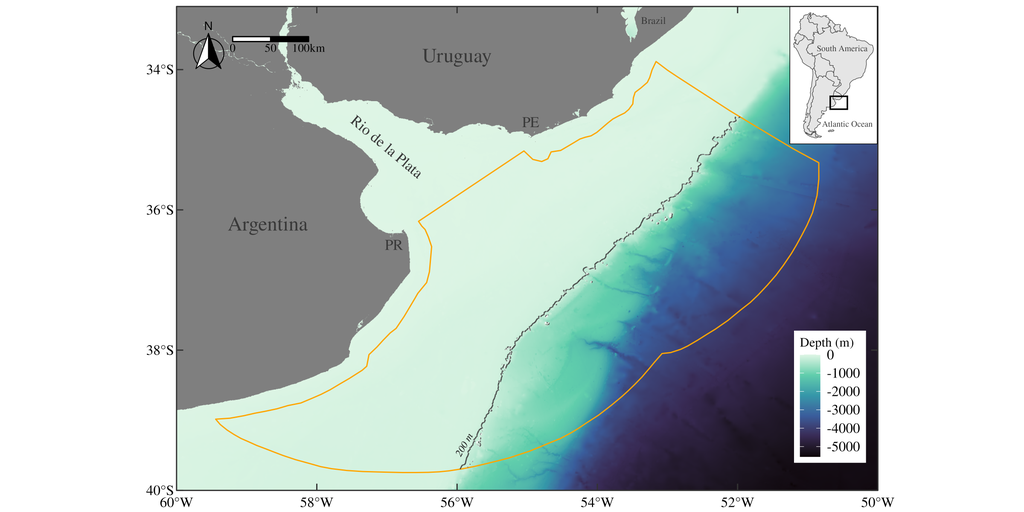

```r
# ============ MAP ======================== ####
# load("time_series_aucfz_data.RData")
aucfz <- as.data.frame(data.set[1]) # Polygon
rs <- raster("datasets/elevation_AUCFZ_ETOPO2022.tiff") # Bathymetry
## Preparing raster object to plot with ggplot2
my_region <- extent(-60, -50, -40, -33.1)
r_points <- rasterToPoints(crop(rs, my_region)) # from raster to points
#  The error that appears at the first time is an "error message" but not a real
#  error in the strict sense as the script continues to run and the results are
#  are not affected. For details, see: https://stackoverflow.com/a/61623381
#
bathy <- data.frame(r_points); rm(r_points) # convert to dataframe
colnames(bathy) <- c("lon", "lat", "elevation")
# Breaks and labels for color scale
zmin <- min(bathy$elevation)
brks <- c(0, -50, -200, -1000, -3000, -5000, zmin)
clabs <- c("(0-50]", "(50-200]", "(200-1000]", "(1000-3000]",
           "(3000-5000]", "> 5000")
bathy$discrete <- cut(bathy$elevation, breaks = brks, labels = clabs) # discrete
# Figure
par(mfcol=c(1,1))
p1 <- map_aucfz(df = bathy, plygn = aucfz, scale = "continuous", clabs) +
  geom_contour_tanaka(
    data = bathy[bathy$lat < -34.67 & bathy$lat > -39.7 , ],
    aes(x = lon, y = lat, z = elevation),
    breaks = -200,
    dark = "gray23",
    range = c(0.2, 0.5) # Efecto de relieve sutil
  ) +
    annotate("text", x = -55.9, y = -39.35, angle = 60,
             label = "200 m",
             family = "Times", size = 3, fontface = "italic", color = "grey10")
# South America map
sa_countries <- ne_countries(continent = "South America", returnclass = "sf")
p2 <- ggplot() +
  geom_sf(data=sa_countries, color = "grey22", fill = "grey90") +
  theme(panel.border = element_rect(colour = "black", fill = NA, size=0.5),
        panel.grid.major = element_blank(),
        panel.background = element_rect(fill = "white"),
        axis.title = element_blank(),
        axis.text = element_blank(),
        axis.ticks = element_blank(),
        plot.margin = margin(-0.3, -0.3, -0.3, -0.3, unit = "cm")) +
  # Bounding box
  geom_rect(aes(xmin = -60, xmax = -50, ymin = -40, ymax = -33),
            color = "black", lwd = 0.6, fill = NA) +
  ## Text
  annotate(
    geom = "text", x = -53, y = -7, label = "South America",
    fontface = "plain", family = "Times", color = "grey22", size = 2.5) +
  annotate(
    geom = "text", x = -50, y = -48, label = "Atlantic Ocean",
    fontface = "plain", family = "Times", color = "grey22", size = 2.5)
# Save figure
file_path <- file.path(out_dir_fig, paste0("Fig_1.pdf", sep=""))
# --- as PDF
file_pdf <- gsub(".pdf", ".pdf", file_path)
pdf(file_path, width=12, height=6, bg = "transparent", colormodel = "cmyk", compress = T)
grid.newpage()
v1 <- viewport(width = 1, height = 1, x = 0.5, y = 0.5)
v2 <- viewport(width = 0.23, height = 0.23, x = 0.814, y = 0.853)
print(p1, vp = v1)
print(p2, vp = v2)
invisible(dev.off())
# --- as PNG
file_png <- gsub(".pdf", ".png", file_path)
ragg::agg_png(file_png, width=12, height=6, units="in", res=600)
grid.newpage()
print(p1, vp = v1); print(p2, vp = v2)
invisible(dev.off())
# HTML
if (knitr::is_html_output()) {
  if (file.exists(file_png)) {
    knitr::include_graphics(file_png)
    } else {
      message("Warning: figure not saved in local yet")
      cat("**Figure not saved in local yet**")
    }
}
```

**Figure 1.-** Geographic location of the study area in the Southwestern Atlantic Continental Shelf (SWACS). The area enclosed by the orange polygon corresponds to the Argentinean-Uruguayan Common Fishing Zone (AUCFZ). PR: Punta Rasa del Cabo San Antonio; PE: Punta del Este. Background colors represent bathymetry data from NOAA (2022). The transition from the continental shelf to the slope is highlighted by the 200 m isobath (dark gray line).

# **Dynamic Time Warping (DTW)**

### Load fishing data and preliminary analyses

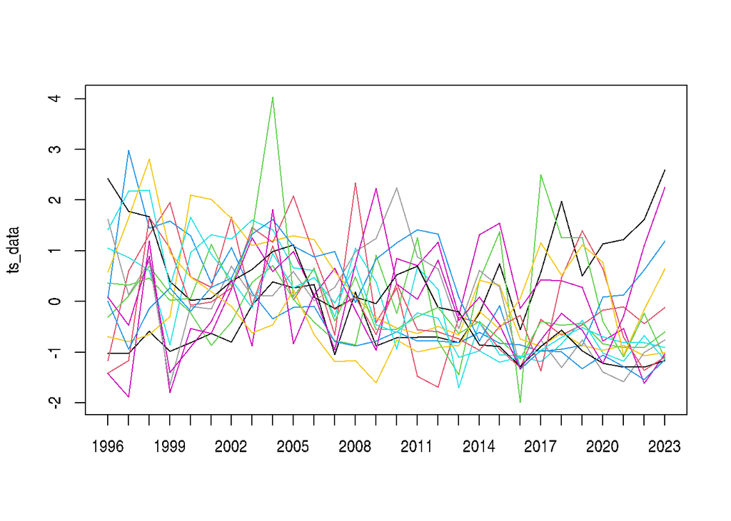

```r
df <- as.data.frame(data.set[2]) # Landings
sp_names <- unique(df %>% dplyr::select(4)) # getting species names
sc_names <- unique(df %>% dplyr::select(5)) # getting species names
# Grouping by year and species names
summary_data <- df %>%
  dplyr::group_by(Year, Common_name) %>%
  dplyr::summarise(
    Total = sum(Landing, na.rm = TRUE),
    Scientific_name = first(Scientific_name),  # Keep the first occurrence
    .groups = 'drop') # ensures resulting dataframe is a non-grouped df
# Shortening scientific name
summary_data <- summary_data %>%
  mutate(Scientific_name = gsub("^(\\w)\\w+ (.*)", "\\1. \\2", Scientific_name))
# Split the summarized data into a list, each species as a separate dataframe
species_list <- split(summary_data, summary_data$Common_name)
# Pivot the summary data to wide format
sp <- summary_data[ ,c(1,3,4)]
wide_data <- sp %>%
  pivot_wider(
    names_from = Year,  # Column names will be years
    values_from = Total # Values will be the total landings
  )
# Scientific name to row's
wide_data <- wide_data %>%
  column_to_rownames(var = "Scientific_name")
# Calculating CVs
cv_results <- sapply(1:nrow(wide_data), function(i){
  row_data <- as.numeric(wide_data[i, ])
  sd(row_data, na.rm = T)/mean(row_data, na.rm = T)*100
})
cv_df <- as.data.frame(cv_results, row.names = row.names(wide_data))
# Keep only species with CV is lower than 100
cv_n <- row.names(cv_df)[cv_df$cv_results < 100]
wide_data <- wide_data[row.names(wide_data) %in% cv_n, ]
# List comprehension to z-score normalization of data
lstls <- to_list(
  for(i in 1:nrow(wide_data))
    (wide_data[i,] - rowMeans(wide_data[i,], na.rm = T)) / sd(wide_data[i,])
)
data <- do.call(rbind, lstls)
ts_data <- ts(t(data))
# Plot time series to check if they were standardized
matplot(ts_data, type = "l", lty = 1, col = 1:ncol(ts_data), xaxt = "n")
axis(1, at = seq_along(ts_data[, 1]), labels =  colnames(data)) # Customize x-axis
```

*Illustrative plot of z-score normalized time series for internal validation (not included in the main manuscript).*

### Testing the number of optimal clusters

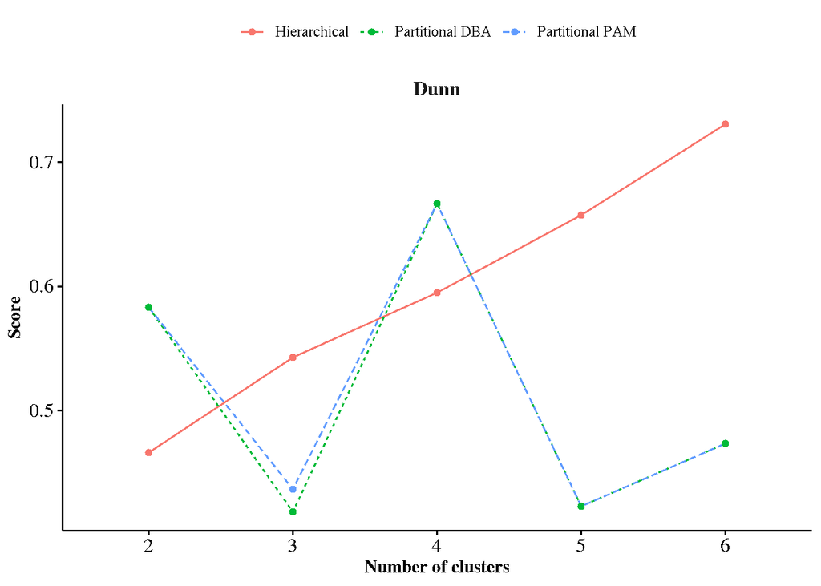

```r
# Cluster evaluation ####
fix_seed <- 72 # Setting a seed ensures that any random initialization within
# the clustering process is reproducible
ks <- 2L:6L
cvi_idx <- c("D")
# ### HIERARCHICAL - DTW basic - SHAPE EXTRACTION - COMPLETE ### =============
hc <- tsclust(
  data, # wide_data, preproc = zscore,
  type = "hierarchical",
  k = ks,
  # norm = "L2", # normalization / euclidean distance
  distance = "dtw_basic",
  centroid = shape_extraction,
  centroid_args = list(znorm = FALSE),
  control = hierarchical_control(method = "complete"),
  window.size = round(ncol(data)*0.10),
  seed = fix_seed
)
names(hc) <- paste0(ks)
cvi_hc <- sapply(hc, cvi, type = cvi_idx)
# ### PAM ### =================================================================
pc_pam <- tsclust(
  data,
  type = "partitional",
  k = ks,
  distance = "dtw_basic",
  centroid = "pam",
  window.size = round(ncol(data)*0.10),
  seed = fix_seed
)
names(pc_pam) <- paste0(ks)
cvi_pc_pam <- sapply(pc_pam, cvi, type = cvi_idx)
# ### DBA ###  ================================================================
pc_dba <- tsclust(
  data,
  type = "partitional",
  k = ks,
  distance = "dtw_basic",
  centroid = "dba",
  window.size = round(ncol(data)*0.10),
  seed = fix_seed
)
names(pc_dba) <- paste0(ks)
cvi_pc_dba <- sapply(pc_dba, cvi, type = cvi_idx)
# ### Plot ### ================================================================
cvi_list <- list(cvi_hc, cvi_pc_pam, cvi_pc_dba) # Merging CVIs
cvi_list <- lapply(cvi_list, function(x) {
  x <- matrix(x, nrow = 1)
  rownames(x) <- "Dunn" # Assign the row names c(Dunn")
  colnames(x) <- ks
  return(x) # Return the modified element
})
cvi_df <- list_to_df(cvi_list,
                     legend_labels = c(
                       "Hierarchical", "Partitional PAM", "Partitional DBA"))
# Plot CVI to select best "k"
file_path <- file.path(out_dir_fig, paste0("Fig_2.pdf", sep=""))
# --- as PDF
file_pdf <- gsub(".pdf", ".pdf", file_path)
pdf(file_path, width=9, height=6, bg = "transparent", colormodel = "cmyk", compress = T)
plot_cvi(cvi_df)
invisible(dev.off())
# --- as PNG
file_png <- gsub(".pdf", ".png", file_path)
ragg::agg_png(file_png, width=9, height=6, units="in", res=600)
plot_cvi(cvi_df)
invisible(dev.off())
# HTML output
if (knitr::is_html_output()) {
  print(plot_cvi(cvi_df))
  cat("\n\n")
  cat("**Figure 2 .-** Score for Dunn index. ")
  cat(paste("Number of optimal clusters (k) = 4."))
  cat("\n\n---\n\n")
  }
```

**Figure 2 .-** Score for Dunn index. Number of optimal clusters (k) = 4.

### Selecting the best clustering algorithm configuration

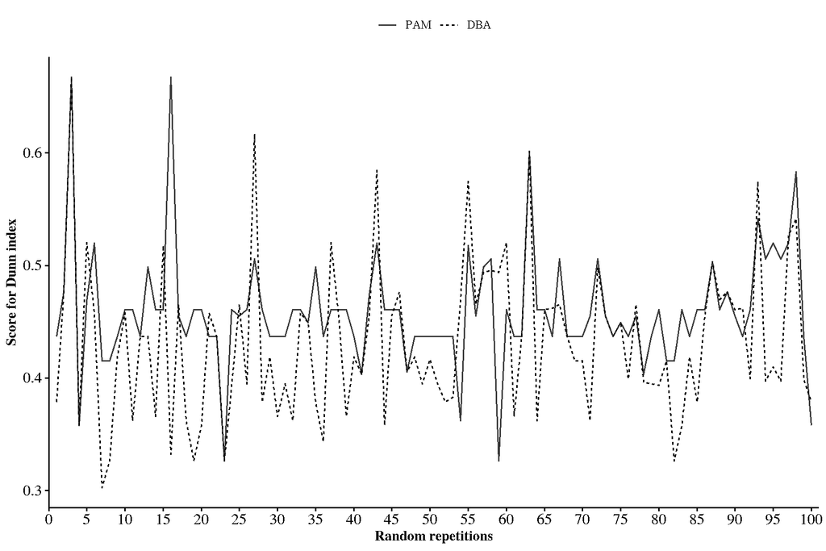

````r
best_k <- 4L
# HIERARCHICAL - best k ====
hc_k <- tsclust(
  data,
  type = "hierarchical",
  k = best_k,
  distance = "dtw_basic",
  centroid = shape_extraction,
  centroid_args = list(znorm = FALSE),
  control = hierarchical_control(method = "complete"),
  window.size = round(ncol(data)*0.10),
  seed = fix_seed
)
cvi_hc_k <- cvi(hc_k, type = cvi_idx)
# plot(hc_k, type = "sc")
# cutree(hc_k, k = best_k)
# PAM - best k - nrep = 100 ====
pc_k_pam_n <- tsclust(
  data,
  type = "partitional",
  k = best_k,
  distance = "dtw_basic",
  centroid = "pam",
  control = partitional_control(nrep = 100L),
  window.size = round(ncol(data)*0.1),
  seed = fix_seed
)
# DBA - best k - nrep = 100 - iter.max = 30 ====
pc_k_dba_n <- tsclust(
  data,
  type = "partitional",
  k = best_k,
  distance = "dtw_basic",
  centroid = "dba",
  control = partitional_control(nrep = 100, iter.max = 30L),
  window.size = round(ncol(data)*0.1),
  seed = fix_seed
)
# Getting best repetition based on Dunn index ====
cvi_detailed_pam <- invisible(best_repetition(pc_k_pam_n, verbose = FALSE))
cvi_detailed_dba <- invisible(best_repetition(pc_k_dba_n, verbose = FALSE))
dunn_values <- cvi_sorted(cvi_detailed_pam, cvi_detailed_dba, "D")
# ```{r}
# Save figure
file_path <- file.path(out_dir_fig, paste0("Fig_S1.pdf", sep=""))
# --- as PDF
file_pdf <- gsub(".pdf", ".pdf", file_path)
pdf(file_path, width=9, height=6, bg = "transparent", colormodel = "cmyk", compress = T)
plot_cvi_values(dunn_values, "Dunn")
invisible(dev.off())
# --- as PNG
file_png <- gsub(".pdf", ".png", file_path)
ragg::agg_png(file_png, width=9, height=6, units="in", res=600)
plot_cvi_values(dunn_values, "Dunn")
invisible(dev.off())
# HTML output
if (knitr::is_html_output()) {
  print(plot_cvi_values(dunn_values, "Dunn"))
  cat("\n\n")
  cat("**Figure S1 .-** Dunn index scores across 100 random repetitions of the partitional clustering method using PAM (solid line) and DBA (dashed line), with optimal number of clusters k = 4.")
  cat("\n\n")
  cat(paste(
  "Best repetition based on Dunn for PAM", round(max(cvi_detailed_pam$D),3),
  "at repetition number", which.max(cvi_detailed_pam$D), "\n",
  "and for DBA:", round(max(cvi_detailed_dba$D),3),
  "at repetition number", which.max(cvi_detailed_dba$D)))
  cat("\n\n---\n\n")
}
````

**Figure S1 .-** Dunn index scores across 100 random repetitions of the partitional clustering method using PAM (solid line) and DBA (dashed line), with optimal number of clusters k = 4.

Best repetition based on Dunn for PAM 0.667 at repetition number 3 and for DBA: 0.667 at repetition number 3

### Clustering results - groups

```r
# Keep the best repetition for PAM and DBA ====
best_PAM <- pc_k_pam_n[[3]]
best_DBA <- pc_k_dba_n[[3]]
# Getting elements in each cluster ====
cat("Hierarchical approach")
cat("\n\n")
cutree(hc_k, k = best_k)
cat("\n\n------------------------------\n\n")
#
cat("Partitional approach - PAM")
cat("\n\n")
setNames(best_PAM@cluster, rownames(data))
clusters_pam <- get_cluster_elements(data, best_PAM, k = best_k, verbose = FALSE)
cat("\n\n------------------------------\n\n")
#
cat("Partitional approach - DBA")
cat("\n\n")
setNames(best_DBA@cluster, rownames(data))
clusters_dba <- get_cluster_elements(data, best_DBA, k = best_k, verbose = FALSE)
cat("\n\n------------------------------\n\n")
```

```
Hierarchical approach

    P. saltatrix    S. guggenheim  U. brasiliensis    I. argentinus
               1                2                3                2
     M. furnieri        P. cromis      M. schmitti      C. dumerili
               4                3                3                4
       M. hubbsi  M. magellanicus       P. signata       U. canosai
               4                3                4                4
    C. guatucupa     M. atricauda H. dactylopterus
               4                1                2


------------------------------

Partitional approach - PAM

    P. saltatrix    S. guggenheim  U. brasiliensis    I. argentinus
               3                4                2                1
     M. furnieri        P. cromis      M. schmitti      C. dumerili
               4                2                4                4
       M. hubbsi  M. magellanicus       P. signata       U. canosai
               4                4                4                4
    C. guatucupa     M. atricauda H. dactylopterus
               4                3                1


------------------------------

Partitional approach - DBA

    P. saltatrix    S. guggenheim  U. brasiliensis    I. argentinus
               3                4                2                1
     M. furnieri        P. cromis      M. schmitti      C. dumerili
               4                2                4                4
       M. hubbsi  M. magellanicus       P. signata       U. canosai
               4                4                4                4
    C. guatucupa     M. atricauda H. dactylopterus
               4                3                1


------------------------------
```

### Clustering results - plots

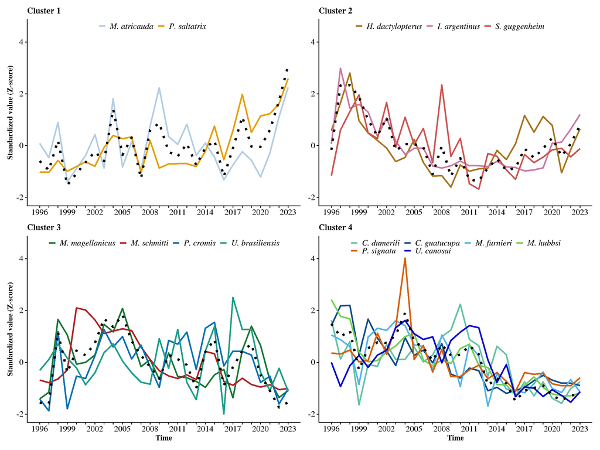

```r
dtw_clust_list <- list(
  HC = list(cutree(hc_k, k = best_k)),
  PAM = list(clusters_pam),
  DBA = list(clusters_dba)
)
years <- colnames(data)
dba_centroids <- get_centroids(best_DBA, years)
save(dba_centroids, file = paste0(out_dir_files, "/centroids_DBA.RData")) #
pam_centroids <- get_centroids(best_PAM, years)
save(pam_centroids, file = paste0(out_dir_files, "/centroids_PAM.RData")) #
hc_centroids <- get_centroids(hc_k, years)
#
dba_series <- get_series(best_DBA, my_colors)
pam_series <- get_series(best_PAM, my_colors)
hc_series <- get_series(hc_k, my_colors)
#
dtw_plot_list <- list(
  HC = list(series = hc_series, centroids = hc_centroids),
  PAM = list(series = pam_series, centroids = pam_centroids),
  DBA = list(series = dba_series, centroids = dba_centroids))
#
numb <- 2
for (p in names(dtw_plot_list)) {
  numb <- numb + 1
  # Save figure
  file_path <- file.path(out_dir_fig, paste0("Fig_", numb, ".pdf", sep="")
    )
  # Create plot object
  plot_element <- dtw_plot_list[[p]]
  plots <- plot_clusters(plot_element$series[[1]], plot_element$centroids,
                         plot_element$series[[2]], years)
  combined_plot <- wrap_plots(plots, ncol = 2) # Combine panels into a single figure
  # --- as PDF
  file_pdf <- gsub(".pdf", ".pdf", file_path)
  pdf(file_path, width=12, height=9, bg = "transparent", colormodel = "cmyk", compress = T)
  print(combined_plot)
  invisible(dev.off())
  # Save to PNG
  file_png <- gsub(".pdf", ".png", file_path)
  ragg::agg_png(file_png, width=12, height=9, units="in", res=600)
  print(combined_plot)
  invisible(dev.off())
}
# Save in the proper order (figure + caption) in the HTML file
if (knitr::is_html_output()) {
  dtw_plot_captions_list <- list(
    HC = list("Hierarchical clustering with DTW distance and shape-extraction centroid using complete linkage, "),
    PAM = list("Partitional clustering with DTW distance and PAM centroids "),
    DBA = list("Partitional clustering with DTW distance and DBA centroids "))
numb <- 2
  for (p in names(dtw_plot_captions_list)) {
    cat("\n\n")
    numb <- numb + 1
    plot_element <- dtw_plot_list[[p]]
    plots <- plot_clusters(plot_element$series[[1]], plot_element$centroids,
                           plot_element$series[[2]], years)
    combined_plot <- wrap_plots(plots, ncol = 2)
    # Print cluster elements
    cat("\n\n")
    print(combined_plot)
    cat("**Figure ", numb, ".-**", dtw_plot_captions_list[[p]][[1]],
        "for k = 4. Solid lines indicate standardized landing time series for each species, while dotted lines represent centroids for each cluster.\n\n")
    cat("\n\n---\n\n")
  }
  cat(paste("Species are distributed equally in both partitional approaches:
            we continue the analyses selecting DBA centroids."))
  cat("\n\n---\n\n")
}
```

**Figure 3 .-** Hierarchical clustering with DTW distance and shape-extraction centroid using complete linkage, for k = 4. Solid lines indicate standardized landing time series for each species, while dotted lines represent centroids for each cluster.

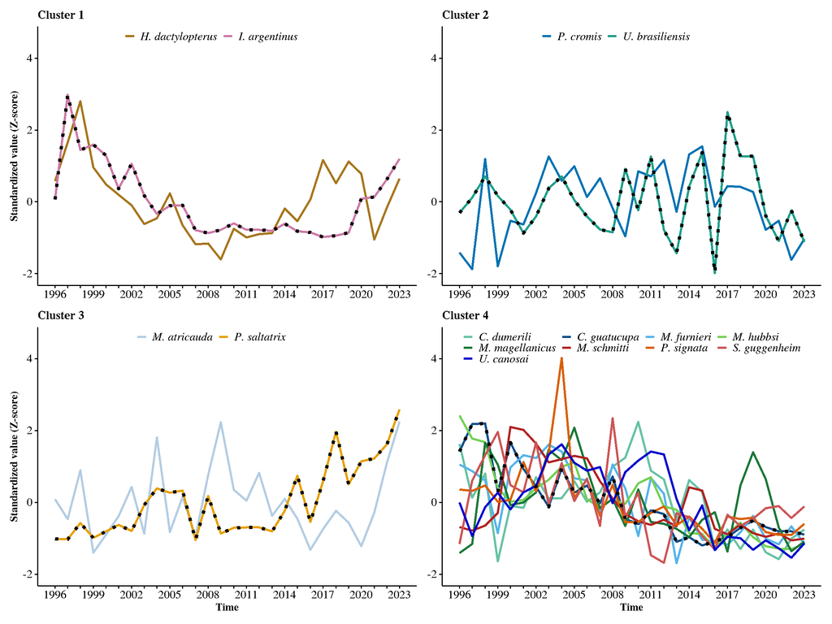

**Figure 4 .-** Partitional clustering with DTW distance and PAM centroids for k = 4. Solid lines indicate standardized landing time series for each species, while dotted lines represent centroids for each cluster.

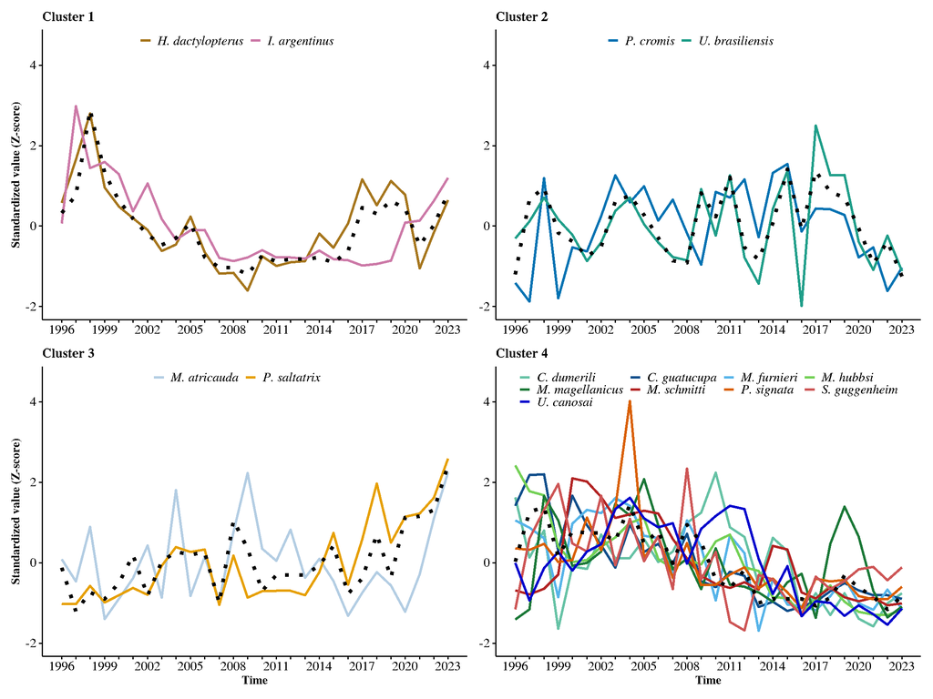

**Figure 5 .-** Partitional clustering with DTW distance and DBA centroids for k = 4. Solid lines indicate standardized landing time series for each species, while dotted lines represent centroids for each cluster.

Species are distributed equally in both partitional approaches: we continue the analyses selecting DBA centroids.

Taking a look into these centroids…

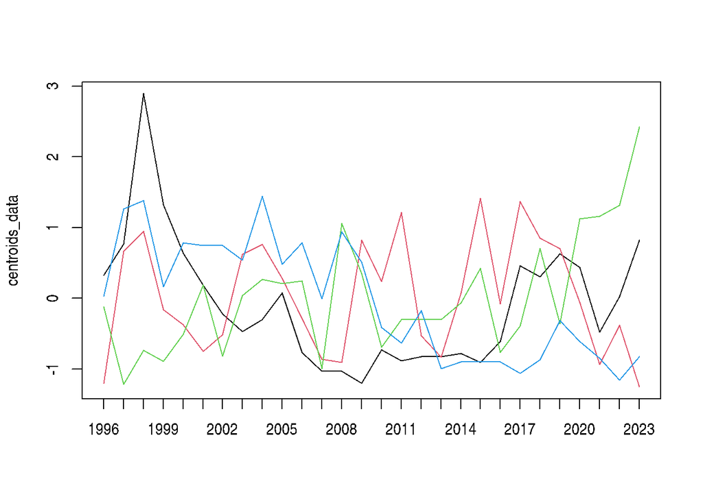

```r
# Extracting centroids for each cluster ---------------------------------------
centroid_idx <- best_DBA@centroids
centroids <- do.call(rbind, centroid_idx)
# ts.plot(t(centroids))
centroids_data <- ts(t(centroids))
rownames(centroids) <- c("I", "II", "III" , "IV")
colnames(centroids) <- colnames(data)
# Plot time series to check centroids
matplot(centroids_data, type = "l", lty = 1, col = 1:ncol(centroids_data), xaxt = "n")
axis(1, at = seq_along(centroids_data[, 1]), labels =  colnames(data))
```

*Illustrative plot of DBA centroids time series for internal validation (not included in the main manuscript).*

# **Dynamic Factor Analysis (DFA)**

### Testing the number of optimal trends

```r
yrs <- colnames(data)
colnames(data) <- NULL
# get number and length of time series
ts_n <- dim(data)[1]
ts_l <- dim(data)[2]
y_bar <- data # landings
dat <- as.matrix(data)
rownames(dat) <- rownames(data)
#
set.seed(123)  # reproducibility
dfa_models <- list()
aicc_vals <- c()
ordinals <- c("1st", "2nd", "3rd", "4th", "5th", "6th")
for (m in 1:6) {
  cat("Fitting", ordinals[m], "DFA model | ")
  dfa_models[[as.character(m)]] <- fit_dfa(m, dat, ts_n)
  aicc_vals[as.character(m)] <- dfa_models[[as.character(m)]]$AICc
  cat("--------------------------------\n")
}
best_m <- names(which.min(aicc_vals))
aicc_table <- round(data.frame(
  m = 1:6,
  AICc = aicc_vals,
  delta_AICc = aicc_vals - min(aicc_vals)),2
  )
aicc_summary <- aicc_table[ ,c(1,3)]
kable(aicc_summary,
      col.names = c("M", "ΔAICc"),
      align = "ccc",
      row.names = FALSE,
      caption = "DFA model selection results based on ΔAICc.") %>%
  kable_styling(full_width = FALSE, position = "left")
cat("Best model is with", best_m, "trends\n")
```

```
Fitting 1st DFA model | Success! abstol and log-log tests passed at 237 iterations.
MARSS fit is
Estimation method: kem
Convergence test: conv.test.slope.tol = 0.01, abstol = 0.001
Estimation converged in 237 iterations.
Log-likelihood: -506.5464
AIC: 1075.093   AICc: 1080.206
--------------------------------
Fitting 2nd DFA model | Success! abstol and log-log tests passed at 401 iterations.
MARSS fit is
Estimation method: kem
Convergence test: conv.test.slope.tol = 0.01, abstol = 0.001
Estimation converged in 401 iterations.
Log-likelihood: -452.4023
AIC: 998.8045   AICc: 1010.934
--------------------------------
Fitting 3rd DFA model | Success! abstol and log-log tests passed at 457 iterations.
MARSS fit is
Estimation method: kem
Convergence test: conv.test.slope.tol = 0.01, abstol = 0.001
Estimation converged in 457 iterations.
Log-likelihood: -422.1625
AIC: 970.3251   AICc: 992.9768
--------------------------------
Fitting 4th DFA model | Success! abstol and log-log tests passed at 408 iterations.
MARSS fit is
Estimation method: kem
Convergence test: conv.test.slope.tol = 0.01, abstol = 0.001
Estimation converged in 408 iterations.
Log-likelihood: -422.1625
AIC: 1002.325   AICc: 1039.502
--------------------------------
Fitting 5th DFA model | Success! abstol and log-log tests passed at 443 iterations.
MARSS fit is
Estimation method: kem
Convergence test: conv.test.slope.tol = 0.01, abstol = 0.001
Estimation converged in 443 iterations.
Log-likelihood: -422.1625
AIC: 1034.325   AICc: 1090.621
--------------------------------
Fitting 6th DFA model | Success! abstol and log-log tests passed at 440 iterations.
MARSS fit is
Estimation method: kem
Convergence test: conv.test.slope.tol = 0.01, abstol = 0.001
Estimation converged in 440 iterations.
Log-likelihood: -422.1625
AIC: 1066.325   AICc: 1147.052
--------------------------------
```

DFA model selection results based on ΔAICc.

| M | ΔAICc |
| --- | --- |
| 1 | 87.23 |
| 2 | 17.96 |
| 3 | 0.00 |
| 4 | 46.52 |
| 5 | 97.64 |
| 6 | 154.08 |

```
Best model is with 3 trends
```

### Temporal patterns of the three common hidden trends and factor loadings of each species

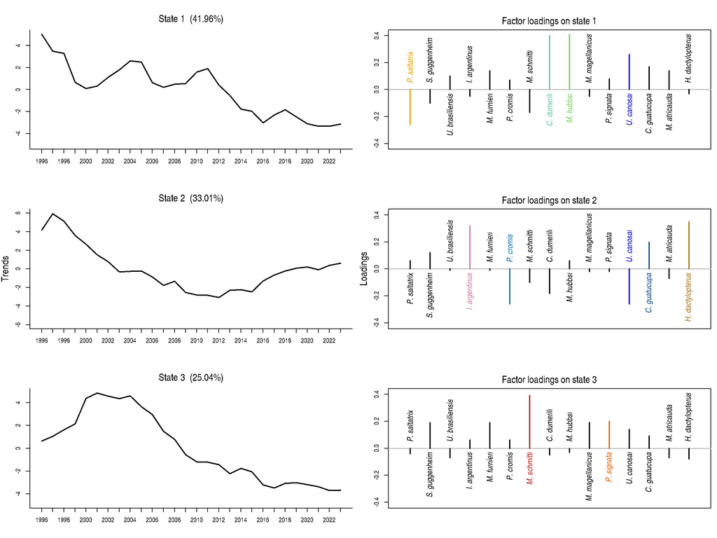

```r
dfa_best <- dfa_calculations(dfa_models[[best_m]], dat, threshold = 0.2)
states_dfa <- dfa_best[["proc_rot"]]
save(states_dfa, file = paste0(out_dir_files,'/states_DFA.RData')) # save common hidden trends
file_path = paste0(file = out_dir_fig, "/Fig_6.pdf", sep="")
# --- as PDF
file_pdf <- gsub(".pdf", ".pdf", file_path)
pdf(file_pdf, width=12, height=10, bg = "transparent", colormodel = "cmyk", compress = T)
par(mfrow = c(1,1),
    oma = c(2, 3, 2, 3),
    mar = c(2,2,1,1)) # oma: bottom, left, top, right
dfa_fig <- dfa_plot(dfa_best,  dat, yrs, clr = my_colors, threshold = 0.2)
invisible(dev.off())
# --- as PNG for HTML
file_png <- gsub(".pdf", ".png", file_path)
ragg::agg_png(file_png, width=12, height=10, units="in", res=600)
par(mfrow = c(1,1),
    oma = c(2, 3, 2, 3),
    mar = c(2,2,1,1)) # oma: bottom, left, top, right
dfa_fig <- dfa_plot(dfa_best,  dat, yrs, clr = my_colors, threshold = 0.2)
invisible(dev.off())
# HTML
if (knitr::is_html_output()) {
  dfa_fig <- dfa_plot(dfa_best,  dat, yrs, clr = my_colors, threshold = 0.2)
  cat("**Figure 6 .-** Estimated common trends in the catches of 15 species obtained from the dynamic factor model with three common trends (the proportion of variance explained by each trend is shown in parentheses) (left panel), and corresponding factor loadings for each species on the three trends (name species in colour indicate loadings >= 0.2) (right panels). Note: common trends and factor loadings are unitless.")
  cat("\n\n---\n\n")
    }
```

**Figure 6 .-** Estimated common trends in the catches of 15 species obtained from the dynamic factor model with three common trends (the proportion of variance explained by each trend is shown in parentheses) (left panel), and corresponding factor loadings for each species on the three trends (name species in colour indicate loadings >= 0.2) (right panels). Note: common trends and factor loadings are unitless.

### Residual diagnosis

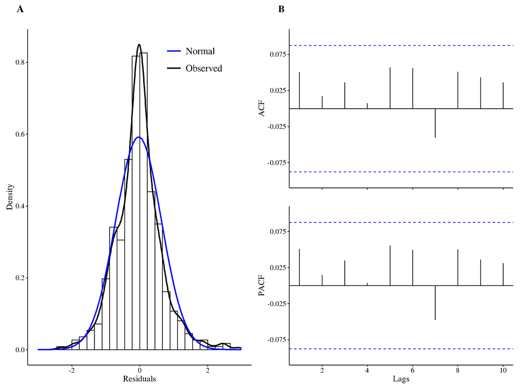

```r
# Extract standardized residuals
resid_df <- na.omit(melt(dfa_best$resid_smooth)) # convert to long format
colnames(resid_df) <- c("series", "time", "residual")
res_df <- data.frame(residual = resid_df$residual)
# Histogram of residuals
p1 <- ggplot(res_df, aes(x = residual)) +
    geom_histogram(aes(y = ..density..),
                   bins = 28,
                   fill = "white", color = "black") +
    stat_density(aes(
      color = "Observed"),
      size = 1,
      geom= "line",
      linetype = "solid"
      ) +
    stat_function(fun = dnorm,
                  args = list(mean = mean(res_df$residual),
                              sd   = sd(res_df$residual)),
                  aes(color = "Normal",
                      linetype = "Normal"), size = 1,linetype = "solid"
                  ) +
    labs(title = "",  # Residuals Histogram",
         x = "Residuals", y = "Density") +
    scale_color_manual(name = NULL,
                       values = c("Observed" = "black",
                                  "Normal" = "blue")) +
    xlim(-3, 3) +
    labs(subtitle = "A") +
    theme_tufte() +
    theme(axis.line = element_line(colour = "black"),
          axis.ticks = element_line(colour="black")) +
    theme(axis.text = element_text(color = "black", size = 12)) +
    theme(axis.text=element_text(size=12),
          axis.title=element_text(size=14,face="plain")) +
    theme(legend.title = element_blank(),
          legend.position = c(0.6, 0.97),
          legend.justification = c("left", "top"),
          legend.direction = "vertical",
          legend.key = element_blank(),
          legend.text = element_text(size = 16),
          legend.key.size = unit(1, "cm")) +
  theme(plot.subtitle = element_text(
      size=17, face = "bold", hjust = -0.05, vjust = 6))
# ACF and PACF of residuals
p2 <- correlograms.plot(x = res_df$residual,
                  lags = 10,
                  upperindex = "B",
                  y_breaks = TRUE
                  )
final_plot <- p1 + p2
# Save figure
file_path = paste0(file = out_dir_fig, "/Fig_S2.pdf", sep="")
# --- as PDF
file_pdf <- gsub(".pdf", ".pdf", file_path)
pdf(file_pdf, width=9, height=6, bg = "transparent", colormodel = "cmyk", compress = T)
par(mfrow = c(1,1),
    oma = c(2, 3, 2, 3),
    mar = c(2,2,1,1)) # oma: bottom, left, top, right
print(final_plot)
invisible(dev.off())
# --- as PNG
file_png <- gsub(".pdf", ".png", file_path)
ragg::agg_png(file_png, width=9, height=6, units="in", res=600)
par(mfrow = c(1,1),
    oma = c(2, 3, 2, 3),
    mar = c(2,2,1,1)) # oma: bottom, left, top, right
print(final_plot)
invisible(dev.off())
# HTML output
if (knitr::is_html_output()) {
  print(final_plot)
}
```

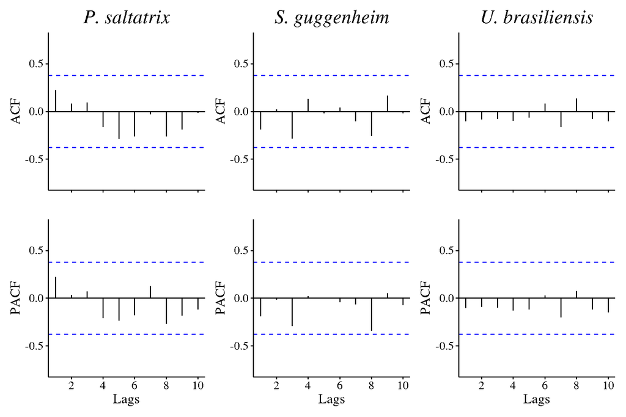

```r
# Check residuals autocorrelation for each species
std_resid <- dfa_best$resid_std[1:15, ]
for (g in 1:5) {
  # $$$ Ruta base: construimos el nombre sin extensión para reusarlo
  file_name <- file.path(out_dir_fig, paste0("Fig_S", g + 2))
  idx <- ((g - 1) * 3 + 1):(g * 3)
  plot_list <- list()
  for (i in idx) {
    species_data <- as.numeric(na.omit(std_resid[i, ]))
    species_name <- rownames(wide_data)[i]
    p <- correlograms.plot(
      species_data,
      lags = 10,
      main = species_name,
      y_lim = c(-0.75, 0.75),
      y_breaks = NULL
    )
    plot_list[[length(plot_list) + 1]] <- p
  }
  combined_plot <- patchwork::wrap_plots(plot_list, ncol = 3)

  # --- as PDF
  file_pdf <- paste0(file_name, ".pdf")
  pdf(file_pdf, width = 9, height = 6, bg = "transparent", colormodel = "cmyk", compress = TRUE)
  print(combined_plot)
  invisible(dev.off())
  # --- as PNG
  file_png <- paste0(file_name, ".png")
  ragg::agg_png(file_png, width = 9, height = 6, units = "in", res = 600)
  print(combined_plot)
  invisible(dev.off())
  # HTML output
  if (knitr::is_html_output()) {
    cat("\n\n")
    print(combined_plot)
    species_caption <- paste(rownames(wide_data)[idx], collapse = ", ")
    cat("\n\n**Figure S", g + 2, ".-** ",
        "Correlograms of the autocorrelation function (ACF, upper row) ",
        "and the partial autocorrelation function (PACF, lower row) ",
        "for the residuals of the best-supported Dynamic Factor Analysis ",
        "(DFA) model for *", species_caption, "*.\n\n", sep = "")
    cat("\n\n---\n\n")
  }
}
```

**Figure S3.-** Correlograms of the autocorrelation function (ACF, upper row) and the partial autocorrelation function (PACF, lower row) for the residuals of the best-supported Dynamic Factor Analysis (DFA) model for *P. saltatrix, S. guggenheim, U. brasiliensis*.

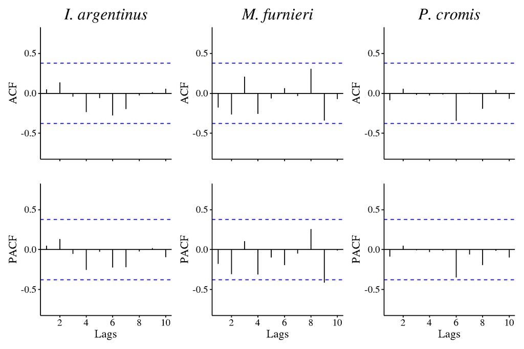

**Figure S4.-** Correlograms of the autocorrelation function (ACF, upper row) and the partial autocorrelation function (PACF, lower row) for the residuals of the best-supported Dynamic Factor Analysis (DFA) model for *I. argentinus, M. furnieri, P. cromis*.

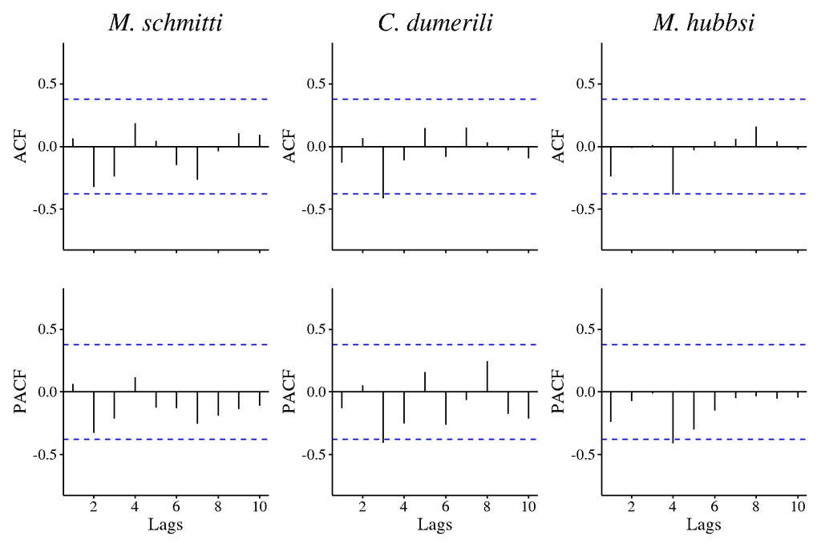

**Figure S5.-** Correlograms of the autocorrelation function (ACF, upper row) and the partial autocorrelation function (PACF, lower row) for the residuals of the best-supported Dynamic Factor Analysis (DFA) model for *M. schmitti, C. dumerili, M. hubbsi*.

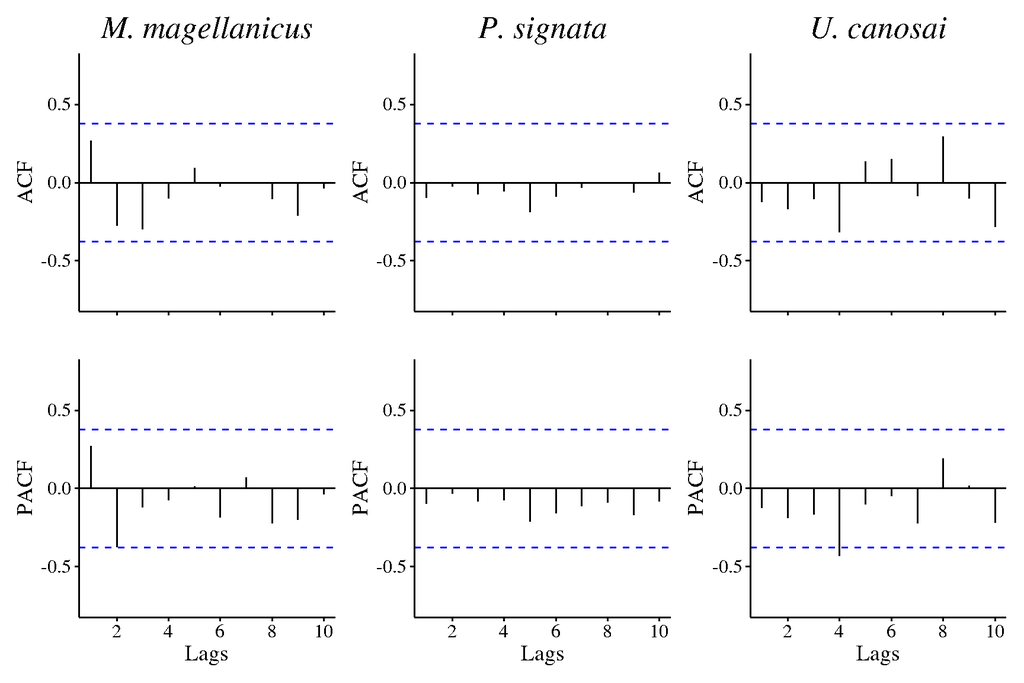

**Figure S6.-** Correlograms of the autocorrelation function (ACF, upper row) and the partial autocorrelation function (PACF, lower row) for the residuals of the best-supported Dynamic Factor Analysis (DFA) model for *M. magellanicus, P. signata, U. canosai*.

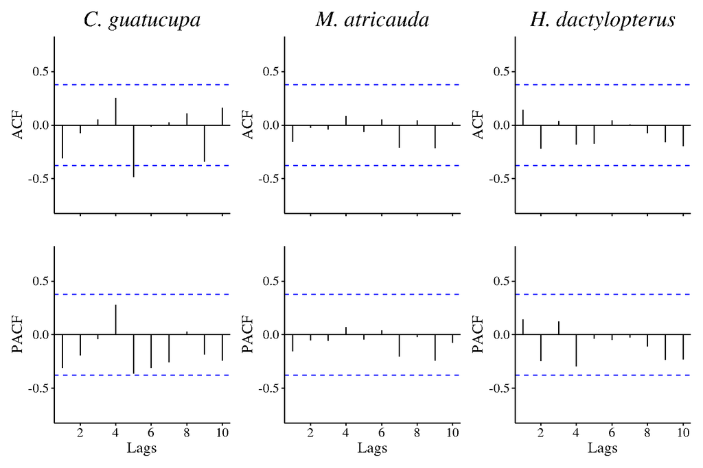

**Figure S7.-** Correlograms of the autocorrelation function (ACF, upper row) and the partial autocorrelation function (PACF, lower row) for the residuals of the best-supported Dynamic Factor Analysis (DFA) model for *C. guatucupa, M. atricauda, H. dactylopterus*.

Observed vs Fitted values for each species

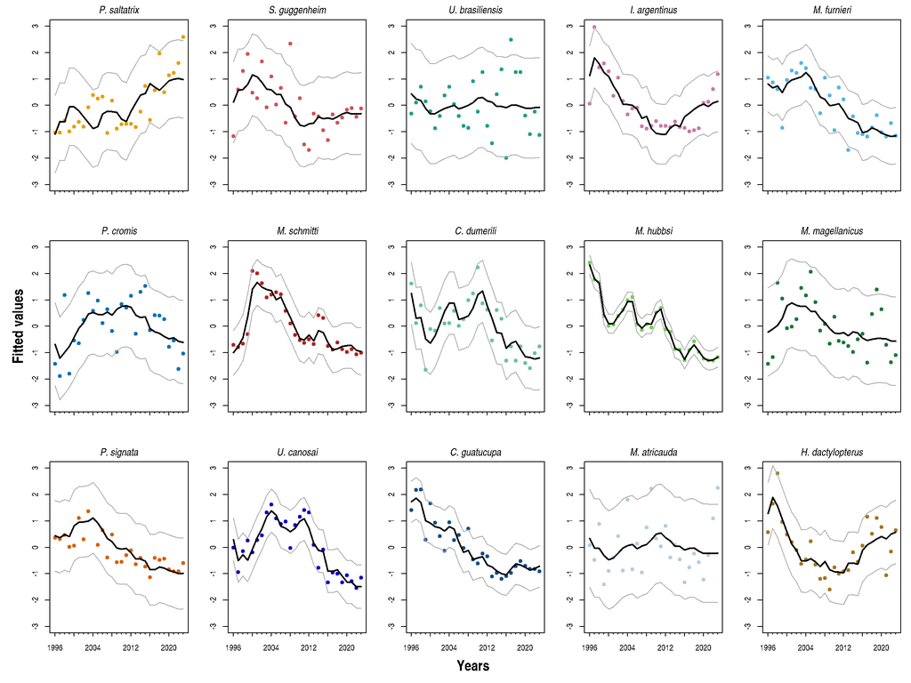

```r
mod_fit_pred <- get_DFA_prediction_intervals(dfa_models[[best_m]])
draw_fit_plots <- function() {
  par(mfrow = c(3, 5), mar = c(3, 3, 2, 1), oma = c(2, 2, 0, 0))
  ylbl <- rownames(dat) # species names
  w_ts <- 1:ncol(dat) # number of years
  ts_n <- nrow(mod_fit_pred$ex) # number of temporal series
  major_ticks <- seq(min(w_ts), max(w_ts), by = 4) # ticks each 4 years
  minor_ticks <- w_ts[!w_ts %in% major_ticks]
  for (i in 1:ts_n) {
    up <- mod_fit_pred$up[i, ]
    mn <- mod_fit_pred$ex[i, ]
    lo <- mod_fit_pred$lo[i, ]
    plot(w_ts, mn,
         xlab = "",
         ylab = "",
         xaxt = "n",
         type = "n",
         cex.lab = 1.2,,
         ylim = c(-3, 3))
    title(main = ylbl[i], font.main = 3)
    axis(1, at = major_ticks, labels = FALSE, tck = -0.023) # ticks large
    axis(1, at = minor_ticks, labels = FALSE, tck = -0.01) # ticks small
    # x-axis
    if (i > ts_n - 5) { # only last row
      axis(1, at = major_ticks, labels = yrs[major_ticks], tick = FALSE, cex.axis = 1)
    }
     # dots and lines
    points(w_ts, dat[i, ], pch = 16, col = my_colors[i])
    lines(w_ts, up, col = "darkgray")
    lines(w_ts, mn, col = "black", lwd = 2)
    lines(w_ts, lo, col = "darkgray")
    if (i == 6) { mtext("Fitted values", side = 2, line = 2.5, at = 0, cex = 1.2, font = 2) }
    if (i == 13) { mtext("Years", side = 1, line = 3, at = 14, cex = 1.2, font = 2)
    }
  }
}

# Save figure
file_path <- file.path(out_dir_fig, "Fig_7")
# --- as PDF
pdf(paste0(file_path, ".pdf"), width = 12, height = 9, colormodel = "cmyk")
draw_fit_plots()
invisible(dev.off())
# --- as PNG
ragg::agg_png(paste0(file_path, ".png"), width = 12, height = 9, units = "in", res = 600)
draw_fit_plots()
invisible(dev.off())
# HTML output
if (knitr::is_html_output()) {
  cat("\n\n")
  draw_fit_plots()
  cat("\n\n**Figure 7.-** Observed (dots), fitted (black lines) and pointwise 95% confidence intervals (grey lines) obtained by the dynamic factor model containing three common trends for each species. Note: values are unitless. \n\n")
}
```

**Figure 7.-** Observed (dots), fitted (black lines) and pointwise 95% confidence intervals (grey lines) obtained by the dynamic factor model containing three common trends for each species. Note: values are unitless.

# **Next section**

**NoteTo continue with this workflow check next sections, which focuses on modeling fishery dynamics through linear (GLM analyses) and non-linear (GAM analyses) techniques:**

Go to Code 2 of 2: GLM and GAM analyses